## Web Applications

#### June 10, 2019

- **Perception of Foreign Accent**  
  This project focused on native English speakers’ perception of L2 speech errors. L2 errors were ranked according to their perceptual accentedness. A Naive Discrimination Model (NDL) was build to approximate accentedness. Preliminary results were published [here](https://content.sciendo.com/view/journals/rela/16/2/article-p135.xml). A web application was developed to implement the NDL method. Click the image below to access the application.

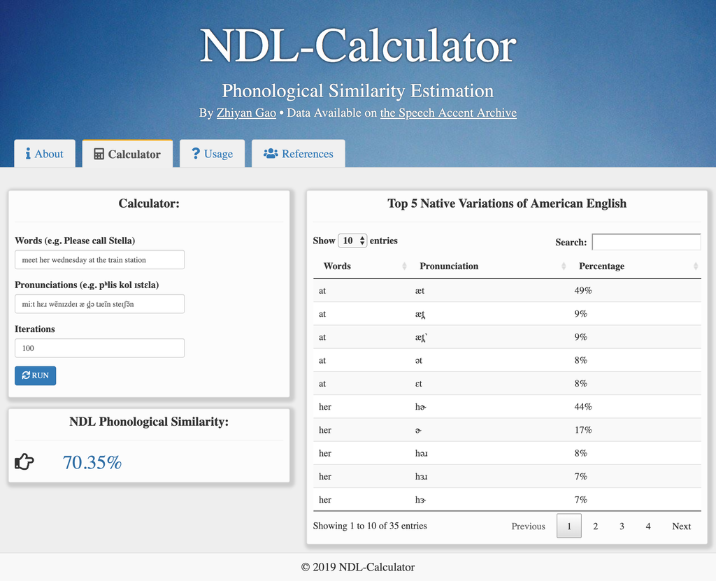

- **南通方言音韵分析**  
  Comparisons between Nantong Chinese and Middle Chinese  
  我为3756个字标注了南通话发音， 例字以及中古声韵调来源为《方言调查字表》（社科院，1981年）。 南通话发音为南通市区发音，以我个人的发音为参考。对于我不确定的字音，我以《南通方言考》中的同音字表为准。 国际音标标注参考了《南通方言考》(敖小平,2017) 语音和历史部分。点击菜单中“字音查询”部分，可查询南通话单字发音。 在此基础上，我制作了这个在线分析系统， 方便对古今音演变感兴趣的朋友作进一步的分析。欢迎各位试用。

[figure not shown]